# NZaidi_LiveSessionAssigment_W2

Najeeb Zaidi

August 7, 2016

## Assignment Requirements:

Use the stackloss data to create the following:

```
 * Use summary() function on data set and interpret the results.
 * Use the ???str??? function on the data set and interpret the results.
 * Create a scatter plot of stack.loss vs. Air.Flow and describe the relationship.
 * Copy and paste the final (error-free) Rmarkdown code into the window provided at 2DS section 2.8.3.
```

### 1. Upload / Read Data:

```r
# reading R package builtin data set
library(datasets)
data(stackloss)

summary(stackloss)
```

```
##     Air.Flow       Water.Temp     Acid.Conc.      stack.loss
##  Min.   :50.00   Min.   :17.0   Min.   :72.00   Min.   : 7.00
##  1st Qu.:56.00   1st Qu.:18.0   1st Qu.:82.00   1st Qu.:11.00
##  Median :58.00   Median :20.0   Median :87.00   Median :15.00
##  Mean   :60.43   Mean   :21.1   Mean   :86.29   Mean   :17.52
##  3rd Qu.:62.00   3rd Qu.:24.0   3rd Qu.:89.00   3rd Qu.:19.00
##  Max.   :80.00   Max.   :27.0   Max.   :93.00   Max.   :42.00
```

### 2A. View Structure of StackLoss dataset:

```r
str(stackloss)
```

```
## 'data.frame':    21 obs. of  4 variables:
##  $ Air.Flow  : num  80 80 75 62 62 62 62 62 58 58 ...
##  $ Water.Temp: num  27 27 25 24 22 23 24 24 23 18 ...
##  $ Acid.Conc.: num  89 88 90 87 87 87 93 93 87 80 ...
##  $ stack.loss: num  42 37 37 28 18 18 19 20 15 14 ...
```

```r
typeof(stackloss$Air.Flow)
```

```
## [1] "double"
```

```r
typeof(stackloss$Water.Temp)
```

```
## [1] "double"
```

```r
typeof(stackloss$Acid.Conc.)
```

```
## [1] "double"
```

```r
typeof(stackloss$stack.loss)
```

```
## [1] "double"
```

```r
head(stackloss)
```

```
##   Air.Flow Water.Temp Acid.Conc. stack.loss
## 1       80         27         89         42
## 2       80         27         88         37
## 3       75         25         90         37
## 4       62         24         87         28
## 5       62         22         87         18
## 6       62         23         87         18
```

### 2B. Interpreting the above results:

**“stackloss”** is a data frame with 21 observations and 4 variables. The type of each vector within this data frame is also listed in output above.

The Header information lists the first 6 records stored in this dataframe. Summary function presented earlier describes the statistical characteristics of data stored in this dataframe.

### 3A. Scatterplot of stack.loss vs. Air.Flow

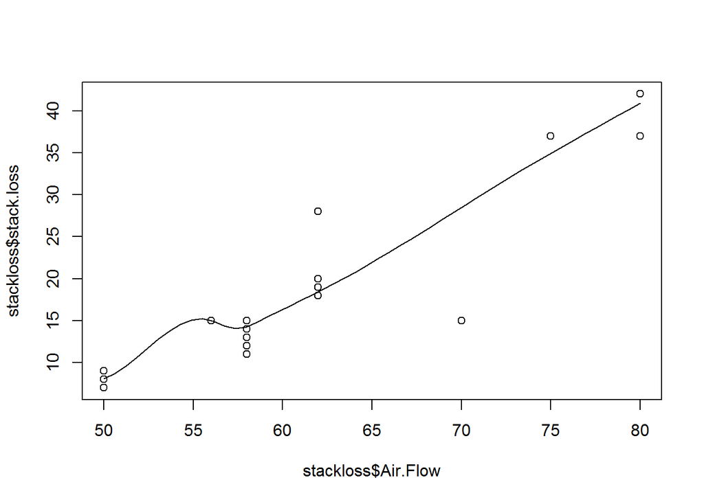

```r
library(ggplot2)
scatter.smooth(stackloss$Air.Flow, stackloss$stack.loss)
```

```r
cor(stackloss$Air.Flow, stackloss$stack.loss)
```

```
## [1] 0.9196635
```

### 3B. Interpretation of Scatterplot

The dataframe suggests that stackloss is a dependent variable of Air Flow, Water Temperature and Acid Concentration levels. This implies that a regression relationship may exist.

**The scatter plot where Air.Flow is taken as ‘x’ or independent variable while stack.loss is the ‘y’ or dependent variable describes a positive linear relationship between these two.**

Additionally, the cor() function computes the correlation between them.

We can further run a linear regression with lm() function and find correation as ANOVA to evaluate the extent and nature of Air Flow impacting the stack.loss.

From [background reading](http://www.calvin.edu/~stob/courses/m241/F11/outlines/Nov20-multilinear.pdf), we get to know that stackloss is dependent variable of a multiple regression where the measurements were collected from an ammonia oxidation plant. Source link provided to view full details.

Najeeb Zaidi - MSDS 6306 .